# main

## Part 1: Linear Neural Networks for Classification

### Question 1: Visualize 10 images from the dataset.

First import dataset. I will try to avoid the d2l library as much as possible and work with native pytorch.

```
60000 10000
```

```
torch.Size([64, 1, 32, 32])
torch.Size([64])
tensor([8, 0, 7, 7, 6, 8, 5, 3, 9, 6, 8, 0, 3, 4, 0, 2, 5, 3, 2, 3, 8, 6, 4, 5,
        5, 4, 6, 2, 1, 3, 1, 3, 2, 6, 4, 6, 4, 1, 5, 4, 3, 3, 0, 9, 9, 9, 1, 7,
        8, 6, 4, 7, 5, 9, 0, 6, 3, 5, 0, 2, 3, 6, 3, 5])
```

```
9
```

```
['T-shirt/top', 'Pullover', 'Ankle boot']
```

```
torch.Size([64, 1, 32, 32]) torch.float32 torch.Size([64]) torch.int64
```

[figure not shown]

### Question 2: Softmax Hyperparameter analysis

```
torch.Size([64, 10])
tensor(2.3348, grad_fn=<NegBackward0>)
```

```
Epoch 1: train loss=0.6402, train acc=0.782, val loss=0.5963, val acc=0.802
Epoch 2: train loss=0.5077, train acc=0.826, val loss=0.5015, val acc=0.824
Epoch 3: train loss=0.4837, train acc=0.835, val loss=0.5377, val acc=0.805
Epoch 4: train loss=0.4667, train acc=0.839, val loss=0.4750, val acc=0.836
Epoch 5: train loss=0.4590, train acc=0.841, val loss=0.4826, val acc=0.832
Epoch 6: train loss=0.4505, train acc=0.844, val loss=0.5085, val acc=0.828
Epoch 7: train loss=0.4468, train acc=0.846, val loss=0.4606, val acc=0.840
Epoch 8: train loss=0.4380, train acc=0.849, val loss=0.4916, val acc=0.827
Epoch 9: train loss=0.4371, train acc=0.849, val loss=0.4827, val acc=0.828
Epoch 10: train loss=0.4345, train acc=0.849, val loss=0.4944, val acc=0.821
Epoch 1: train loss=1.5793, train acc=0.778, val loss=1.0170, val acc=0.790
Epoch 2: train loss=1.2840, train acc=0.799, val loss=2.7868, val acc=0.719
Epoch 3: train loss=1.2477, train acc=0.805, val loss=3.0990, val acc=0.639
Epoch 4: train loss=1.1871, train acc=0.809, val loss=1.3793, val acc=0.770
Epoch 5: train loss=1.1477, train acc=0.812, val loss=1.5838, val acc=0.764
Epoch 6: train loss=1.1619, train acc=0.813, val loss=1.1460, val acc=0.783
Epoch 7: train loss=1.1543, train acc=0.814, val loss=1.6846, val acc=0.769
Epoch 8: train loss=1.1354, train acc=0.813, val loss=0.9746, val acc=0.797
Epoch 9: train loss=1.1148, train acc=0.816, val loss=0.9683, val acc=0.795
Epoch 10: train loss=1.1607, train acc=0.814, val loss=0.9477, val acc=0.806
Epoch 1: train loss=0.5574, train acc=0.863, val loss=0.6444, val acc=0.841
Epoch 2: train loss=0.5170, train acc=0.864, val loss=0.6119, val acc=0.839
Epoch 3: train loss=0.4955, train acc=0.864, val loss=0.5878, val acc=0.838
Epoch 4: train loss=0.4785, train acc=0.864, val loss=0.5887, val acc=0.837
Epoch 5: train loss=0.4653, train acc=0.863, val loss=0.5551, val acc=0.840
Epoch 6: train loss=0.4541, train acc=0.864, val loss=0.5431, val acc=0.842
Epoch 7: train loss=0.4452, train acc=0.864, val loss=0.5395, val acc=0.839
Epoch 8: train loss=0.4371, train acc=0.865, val loss=0.5896, val acc=0.824
Epoch 9: train loss=0.4323, train acc=0.864, val loss=0.5180, val acc=0.841
Epoch 10: train loss=0.4251, train acc=0.865, val loss=0.5175, val acc=0.839
```

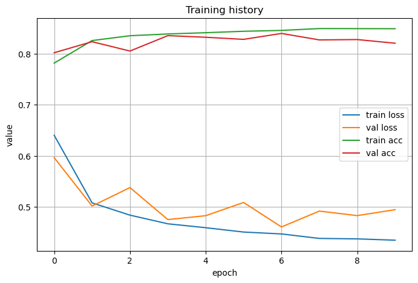

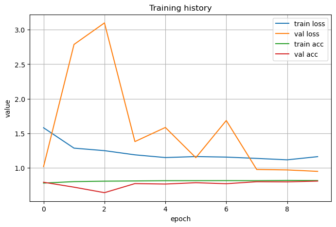

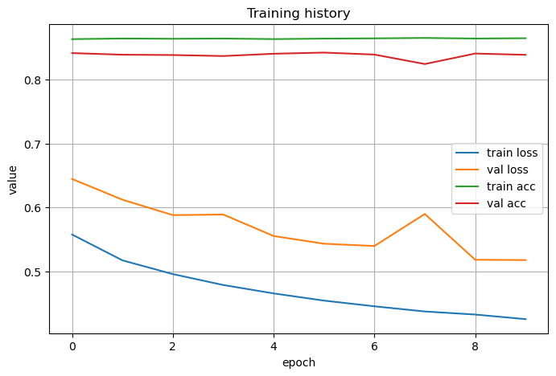

```
=== Training with batch size 15 ===
Epoch 1: train loss=0.6893, train acc=0.788, val loss=0.6086, val acc=0.811
Epoch 2: train loss=0.5827, train acc=0.821, val loss=0.5702, val acc=0.813
Epoch 3: train loss=0.5704, train acc=0.826, val loss=0.6526, val acc=0.814
Epoch 4: train loss=0.5563, train acc=0.830, val loss=0.4978, val acc=0.837
Epoch 5: train loss=0.5470, train acc=0.832, val loss=0.6346, val acc=0.805
Epoch 6: train loss=0.5400, train acc=0.832, val loss=0.5069, val acc=0.836
Epoch 7: train loss=0.5335, train acc=0.834, val loss=0.6989, val acc=0.773
Epoch 8: train loss=0.5336, train acc=0.837, val loss=0.5247, val acc=0.827
Epoch 9: train loss=0.5290, train acc=0.836, val loss=0.6026, val acc=0.824
Epoch 10: train loss=0.5306, train acc=0.836, val loss=0.5751, val acc=0.811

=== Training with batch size 60 ===
Epoch 1: train loss=0.6419, train acc=0.782, val loss=0.5434, val acc=0.810
Epoch 2: train loss=0.5087, train acc=0.826, val loss=0.5489, val acc=0.802
Epoch 3: train loss=0.4800, train acc=0.836, val loss=0.5036, val acc=0.822
Epoch 4: train loss=0.4656, train acc=0.841, val loss=0.5867, val acc=0.803
Epoch 5: train loss=0.4546, train acc=0.844, val loss=0.5432, val acc=0.820
Epoch 6: train loss=0.4503, train acc=0.844, val loss=0.5023, val acc=0.818
Epoch 7: train loss=0.4461, train acc=0.847, val loss=0.4788, val acc=0.830
Epoch 8: train loss=0.4435, train acc=0.847, val loss=0.4617, val acc=0.838
Epoch 9: train loss=0.4367, train acc=0.850, val loss=0.4708, val acc=0.832
Epoch 10: train loss=0.4364, train acc=0.849, val loss=0.4650, val acc=0.837

=== Training with batch size 200 ===
Epoch 1: train loss=0.7426, train acc=0.753, val loss=0.5995, val acc=0.797
Epoch 2: train loss=0.5545, train acc=0.814, val loss=0.5633, val acc=0.802
Epoch 3: train loss=0.5166, train acc=0.824, val loss=0.5204, val acc=0.822
Epoch 4: train loss=0.4935, train acc=0.833, val loss=0.5063, val acc=0.826
Epoch 5: train loss=0.4782, train acc=0.837, val loss=0.4968, val acc=0.826
Epoch 6: train loss=0.4698, train acc=0.840, val loss=0.5109, val acc=0.824
Epoch 7: train loss=0.4608, train acc=0.843, val loss=0.4973, val acc=0.827
Epoch 8: train loss=0.4544, train acc=0.846, val loss=0.4773, val acc=0.833
Epoch 9: train loss=0.4501, train acc=0.847, val loss=0.4715, val acc=0.834
Epoch 10: train loss=0.4462, train acc=0.848, val loss=0.4928, val acc=0.822
```

```
=== Plotting history for batch size 15 ===
```

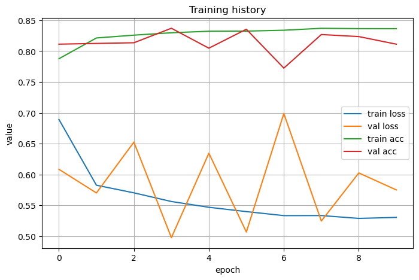

```
=== Plotting history for batch size 60 ===
```

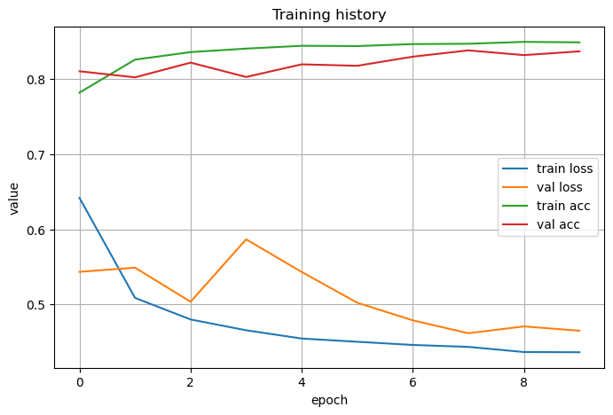

```
=== Plotting history for batch size 200 ===
```

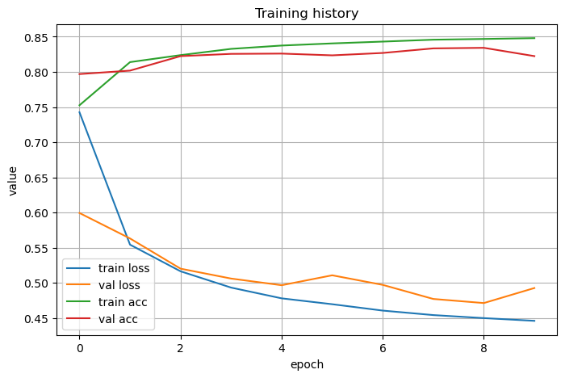

## Part 2: Multilayer Perceptrons (MLPs)

### Question 1: Come up with an example that the gradients vanish for the sigmoid activation function.

The sigmoid is defined as

$$ \sigma(x) = \frac{1}{1 + e^{-x}}, \qquad \sigma'(x) = \sigma(x)\,(1 - \sigma(x)). $$

If $x \gg 0$, then $\sigma(x) \approx 1$, so $\sigma'(x) \approx 0$.

If $x \ll 0$, then $\sigma(x) \approx 0$, so $\sigma'(x) \approx 0$.

This is known as the vanishing gradient problem.To demostrate this effect here some samples:

```
x values:      [-100.  -10.   -5.    0.    5.   10.  100.]
sigmoid(x):   [0.0000000e+00 4.5397872e-05 6.6928510e-03 5.0000000e-01 9.9330717e-01
 9.9995458e-01 1.0000000e+00]
gradients:    [0.0000000e+00 4.5395809e-05 6.6480567e-03 2.5000000e-01 6.6480329e-03
 4.5416677e-05 0.0000000e+00]
```

The output demonstrates how the vanishing gradient problem affects sigmoid activation functions. The sigmoid function outputs 0.5 when x equals 0 and its derivative reaches its highest value at 0.25. The output of the sigmoid function approaches zero while its gradient approaches zero when the absolute value of x grows. The gradient value decreases to 6.6 x 10^-3 when x reaches ±5 and it reaches 4.5 x 10^-5 at x = ±10 and becomes 0 at x = ±100 in floating-point calculations, the gradient has fully vanished. The sigmoid output reaches 0 or 1 at this point. The vanishing gradient problem occurs because neurons in saturated sigmoid states stop learning because their gradients become zero and cannot be updated anymore.

### MLP Implementation

```
Epoch 1: train loss=0.5676, train acc=0.804, val loss=0.4727, val acc=0.832
Epoch 2: train loss=0.4102, train acc=0.853, val loss=0.4419, val acc=0.844
Epoch 3: train loss=0.3733, train acc=0.867, val loss=0.3994, val acc=0.855
Epoch 4: train loss=0.3490, train acc=0.874, val loss=0.3964, val acc=0.858
Epoch 5: train loss=0.3320, train acc=0.881, val loss=0.3924, val acc=0.855
Epoch 6: train loss=0.3192, train acc=0.884, val loss=0.3603, val acc=0.871
Epoch 7: train loss=0.3078, train acc=0.888, val loss=0.3564, val acc=0.873
Epoch 8: train loss=0.2988, train acc=0.891, val loss=0.3515, val acc=0.876
Epoch 9: train loss=0.2908, train acc=0.894, val loss=0.3395, val acc=0.881
Epoch 10: train loss=0.2817, train acc=0.896, val loss=0.3489, val acc=0.871
```

```
standard MLP trained:
```

[figure not shown]

```
MLP with extra layer(128) trained:
```

```
Epoch 1: train loss=0.5585, train acc=0.806, val loss=0.4585, val acc=0.839
Epoch 2: train loss=0.4154, train acc=0.851, val loss=0.4228, val acc=0.856
Epoch 3: train loss=0.3739, train acc=0.865, val loss=0.5165, val acc=0.813
Epoch 4: train loss=0.3521, train acc=0.873, val loss=0.4560, val acc=0.824
Epoch 5: train loss=0.3335, train acc=0.878, val loss=0.3907, val acc=0.860
Epoch 6: train loss=0.3193, train acc=0.884, val loss=0.4201, val acc=0.850
Epoch 7: train loss=0.3085, train acc=0.888, val loss=0.3774, val acc=0.866
Epoch 8: train loss=0.2986, train acc=0.891, val loss=0.3673, val acc=0.867
Epoch 9: train loss=0.2910, train acc=0.894, val loss=0.3989, val acc=0.859
Epoch 10: train loss=0.2834, train acc=0.896, val loss=0.3559, val acc=0.875
```

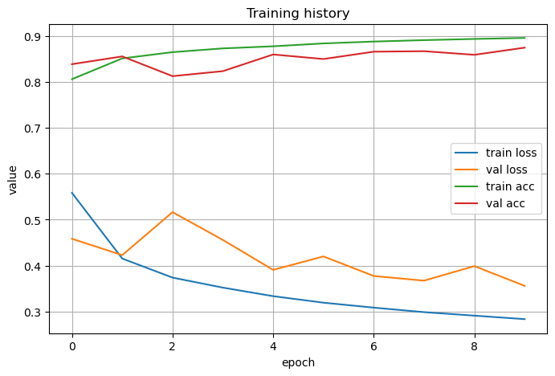

```
MLP with extra layer with single neuron trained:
```

```
Epoch 1: train loss=0.5543, train acc=0.807, val loss=0.4504, val acc=0.841
Epoch 2: train loss=0.4081, train acc=0.854, val loss=0.4123, val acc=0.855
Epoch 3: train loss=0.3733, train acc=0.866, val loss=0.3834, val acc=0.866
Epoch 4: train loss=0.3516, train acc=0.872, val loss=0.4235, val acc=0.847
Epoch 5: train loss=0.3335, train acc=0.880, val loss=0.3750, val acc=0.866
Epoch 6: train loss=0.3204, train acc=0.883, val loss=0.3810, val acc=0.865
Epoch 7: train loss=0.3082, train acc=0.888, val loss=0.3565, val acc=0.873
Epoch 8: train loss=0.2991, train acc=0.891, val loss=0.3492, val acc=0.873
Epoch 9: train loss=0.2903, train acc=0.893, val loss=0.3593, val acc=0.876
Epoch 10: train loss=0.2828, train acc=0.896, val loss=0.3655, val acc=0.870
```

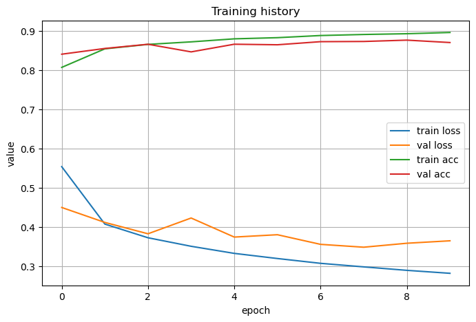

### Question 2: Give it a try to add one hidden layer, show how it affects the results. What if adding a hidden layer with one single neuron, what’s the results? Please discuss what you get and why.

The results demonstrate how network depth and layer size influence performance through a comparison between the baseline MLP with one hidden layer of 256 units and its versions with additional hidden layers. The addition of a second hidden layer with 128 neurons produces no substantial change in results, the training and validation accuracy levels remain at 89-90% and 87-88% respectively which indicates the original model had enough capacity to learn the dataset and additional depth only results in minor representation changes. The second hidden layer with a single neuron creates an extreme information restriction because all class predictions need to be generated from a single-dimensional transformation of the input data which reduces expressiveness and raises validation loss but maintains high validation accuracy because the model learns an effective one-dimensional separation that works well for top-1 classification. The accuracy results hide the models weak representation capabilities and probability accuracy because the bottleneck model generates less confident predictions even though it achieves many correct classifications. The addition of a well-sized hidden layer to the baseline model does not improve performance because the baseline already meets requirements but adding a one-neuron hidden layer severely restricts network capacity which results in slightly worse validation loss values (36.55%) while maintaining similar accuracy because of the simple nature of the data and the strong performance of the initial wide hidden layer.

### Question 3: What’s the memory footprint for training and prediction in the model described in the above example?

For the two-hidden-layer MLP with a bottleneck of size one, we have the following architecture: the input dimension is

$$ d = 32 \times 32 = 1024, $$

the first hidden layer has

$$ h_1 = 256, $$

the second hidden layer has

$$ h_2 = 1, $$

and the output dimension is

$$ q = 10. $$

All computations are performed in single precision (float32), which uses 4 bytes per parameter.

The number of parameters can be computed layer by layer. The first layer has a weight matrix

$$ W_1 \in \mathbb{R}^{1024 \times 256} $$

with $262{,}144$ entries and a bias vector

$$ b_1 \in \mathbb{R}^{256}. $$

The second layer has

$$ W_2 \in \mathbb{R}^{256 \times 1} $$

with $256$ entries and a bias

$$ b_2 \in \mathbb{R}^{1}. $$

The third layer has

$$ W_3 \in \mathbb{R}^{1 \times 10} $$

with $10$ entries and a bias

$$ b_3 \in \mathbb{R}^{10}. $$

Altogether, this yields

$$ 262{,}144 + 256 + 10 + 256 + 1 + 10 = 262{,}677 $$

parameters, which corresponds to

$$ 262{,}677 \times 4 = 1{,}050{,}708 \text{ bytes} \approx 1.0 \text{ MiB}. $$

During training, we also need to store the activations for backpropagation. For each sample, we retain the input

$$ X \in \mathbb{R}^{1024} $$

the first hidden activation

$$ H_1 \in \mathbb{R}^{256} $$

the second hidden activation

$$ H_2 \in \mathbb{R}^{1} $$

and the output logits

$$ \in \mathbb{R}^{10}. $$

This gives

$$ 1024 + 256 + 1 + 10 = 1291 $$

floats per sample, which corresponds to

$$ 1291 \times 4 = 5164 \text{ bytes} $$

For a batch size $B$, the activation memory therefore scales as

$$ 4B \times 1291 \text{ bytes}. $$

The total memory footprint for inference is approximately

$$ M_{\text{infer}} \approx 4\big(\#\text{params} + B \times 1291\big), $$

while the total memory footprint for training is approximately

$$ M_{\text{train}} \approx 4\big(2 \times \#\text{params} + B \times 1291\big). $$

If one uses Adam instead of SGD, an additional factor of about

$$ 2 \times \#\text{params} $$

must be included to account for the first and second moment estimates.

$$ B=64 $$

# Part 3: Basic Convolutional Neural Networks (LeNet)

```
Input shape: torch.Size([1, 1, 32, 32])
Conv1+Sigmoid: torch.Size([1, 6, 28, 28])
Pool1: torch.Size([1, 6, 14, 14])
Conv2+Sigmoid: torch.Size([1, 16, 10, 10])
Pool2: torch.Size([1, 16, 5, 5])
Flatten: torch.Size([1, 400])
FC1+Sigmoid: torch.Size([1, 120])
FC2+Sigmoid: torch.Size([1, 84])
FC3 (logits): torch.Size([1, 10])
```

```
LeNet epochs= 5:
```

```
Epoch 1: train loss=2.3100, train acc=0.098, val loss=2.3105, val acc=0.100
Epoch 2: train loss=2.3072, train acc=0.100, val loss=2.3043, val acc=0.100
Epoch 3: train loss=2.3060, train acc=0.102, val loss=2.3083, val acc=0.100
Epoch 4: train loss=2.3022, train acc=0.110, val loss=2.2952, val acc=0.100
Epoch 5: train loss=2.1794, train acc=0.240, val loss=1.7273, val acc=0.447
```

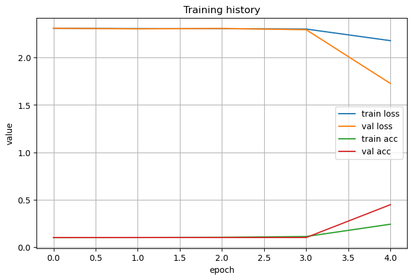

```
LeNet epochs=10:
```

```
Epoch 1: train loss=2.3086, train acc=0.099, val loss=2.3068, val acc=0.100
Epoch 2: train loss=2.3054, train acc=0.101, val loss=2.3028, val acc=0.100
Epoch 3: train loss=2.2817, train acc=0.151, val loss=2.1921, val acc=0.265
Epoch 4: train loss=1.5630, train acc=0.480, val loss=1.1941, val acc=0.540
Epoch 5: train loss=1.0805, train acc=0.594, val loss=0.9995, val acc=0.623
Epoch 6: train loss=0.9356, train acc=0.652, val loss=0.8895, val acc=0.673
Epoch 7: train loss=0.8420, train acc=0.688, val loss=0.8207, val acc=0.698
Epoch 8: train loss=0.7791, train acc=0.708, val loss=0.7734, val acc=0.702
Epoch 9: train loss=0.7309, train acc=0.724, val loss=0.7345, val acc=0.719
Epoch 10: train loss=0.6958, train acc=0.733, val loss=0.7048, val acc=0.735
```

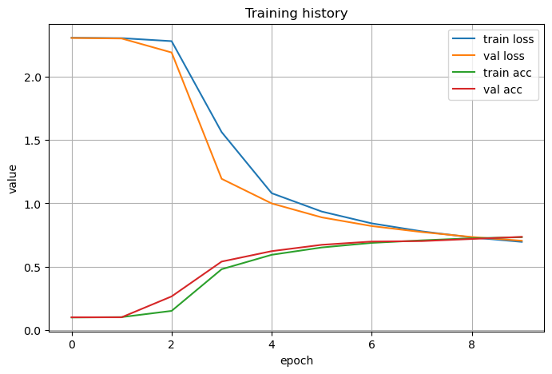

```
LeNet epochs=20:
```

```
Epoch 1: train loss=2.3081, train acc=0.101, val loss=2.3098, val acc=0.100
Epoch 2: train loss=2.3064, train acc=0.103, val loss=2.3065, val acc=0.100
Epoch 3: train loss=2.3008, train acc=0.111, val loss=2.2899, val acc=0.100
Epoch 4: train loss=1.9692, train acc=0.336, val loss=1.3830, val acc=0.516
Epoch 5: train loss=1.1723, train acc=0.568, val loss=1.0496, val acc=0.595
Epoch 6: train loss=0.9797, train acc=0.631, val loss=0.9295, val acc=0.663
Epoch 7: train loss=0.8844, train acc=0.675, val loss=0.8687, val acc=0.694
Epoch 8: train loss=0.8265, train acc=0.695, val loss=0.8172, val acc=0.701
Epoch 9: train loss=0.7792, train acc=0.711, val loss=0.7751, val acc=0.708
Epoch 10: train loss=0.7361, train acc=0.723, val loss=0.7406, val acc=0.729
Epoch 11: train loss=0.7021, train acc=0.734, val loss=0.7097, val acc=0.734
Epoch 12: train loss=0.6746, train acc=0.740, val loss=0.6983, val acc=0.732
Epoch 13: train loss=0.6551, train acc=0.746, val loss=0.6708, val acc=0.743
Epoch 14: train loss=0.6393, train acc=0.752, val loss=0.6555, val acc=0.740
Epoch 15: train loss=0.6259, train acc=0.756, val loss=0.6353, val acc=0.752
Epoch 16: train loss=0.6121, train acc=0.762, val loss=0.6477, val acc=0.755
Epoch 17: train loss=0.6005, train acc=0.766, val loss=0.6165, val acc=0.755
Epoch 18: train loss=0.5903, train acc=0.770, val loss=0.6106, val acc=0.764
Epoch 19: train loss=0.5799, train acc=0.775, val loss=0.5901, val acc=0.774
Epoch 20: train loss=0.5710, train acc=0.778, val loss=0.5941, val acc=0.772
```

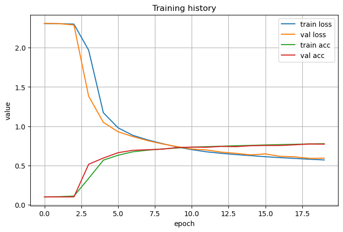

### Question 1: Use different epochs (5, 10, 20) to train your LeNet, plot the training loss, validation loss, and validation accuracy of each training process, and discuss how changing training epochs affects the performance.

The training of LeNet for 5, 10 and 20 epochs demonstrates an accuracy–loss tradeoff which is primarily caused by optimization time. The network remains undertrained after five epochs because validation accuracy remains at chance levels during the first four epochs before reaching 0.45 in the fifth epoch while validation loss remains high at 1.73. The network improves majorly when trained for 10 epochs because losses decrease dramatically during the initial epochs before stabilizing at the end of training while reaching 0.70–0.74 validation accuracy (≈0.735) with validation loss at 0.70. The model achieves better performance at 20 epochs than at 10 epochs because validation accuracy reaches 0.77–0.78 (≈0.772) and validation loss reaches 0.59 while training loss reaches 0.57 without significant degradation between train and validation results. The model achieves its most significant progress when moving from 5 to 10 epochs because it breaks out of random behavior and develops stable features while additional training from 10 to 20 epochs produces smaller but still useful improvements (validation accuracy increases by 4 percentage points and validation loss decreases by 0.11). The architecture and learning rate suggest that early stopping at the best validation point between 15 to 20 epochs would be an optimal choice. The models performance can be improved through faster convergence by replacing sigmoid with ReLU activation which we will do in task 2 or by adding momentum/Adam optimization instead of relying on extra training epochs.

```
=== Training LeNet2 for 5 epochs ===
Epoch 1: train loss=0.7840, train acc=0.709, val loss=0.5378, val acc=0.794
Epoch 2: train loss=0.4686, train acc=0.826, val loss=0.4774, val acc=0.824
Epoch 3: train loss=0.3989, train acc=0.854, val loss=0.3980, val acc=0.855
Epoch 4: train loss=0.3568, train acc=0.868, val loss=0.3947, val acc=0.856
Epoch 5: train loss=0.3289, train acc=0.880, val loss=0.3667, val acc=0.863
```

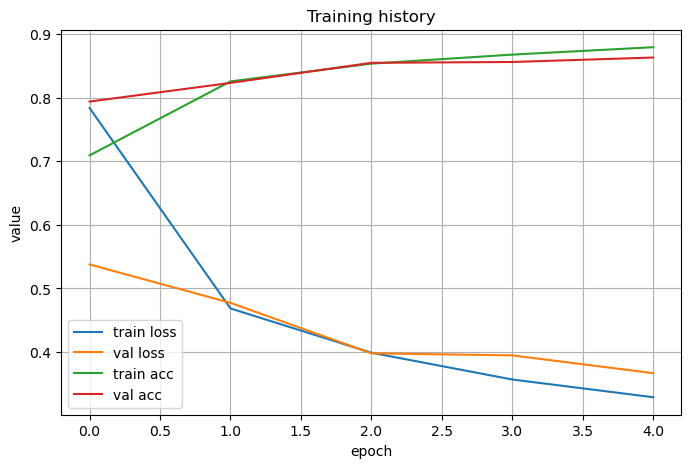

```
=== Training LeNet2 for 10 epochs ===
Epoch 1: train loss=0.8239, train acc=0.691, val loss=0.5454, val acc=0.797
Epoch 2: train loss=0.4754, train acc=0.822, val loss=0.4547, val acc=0.829
Epoch 3: train loss=0.3992, train acc=0.852, val loss=0.4232, val acc=0.843
Epoch 4: train loss=0.3606, train acc=0.867, val loss=0.4082, val acc=0.848
Epoch 5: train loss=0.3365, train acc=0.876, val loss=0.4009, val acc=0.851
Epoch 6: train loss=0.3184, train acc=0.882, val loss=0.3531, val acc=0.869
Epoch 7: train loss=0.3009, train acc=0.888, val loss=0.3627, val acc=0.869
Epoch 8: train loss=0.2875, train acc=0.893, val loss=0.3557, val acc=0.873
Epoch 9: train loss=0.2772, train acc=0.897, val loss=0.3401, val acc=0.873
Epoch 10: train loss=0.2659, train acc=0.900, val loss=0.3268, val acc=0.887
```

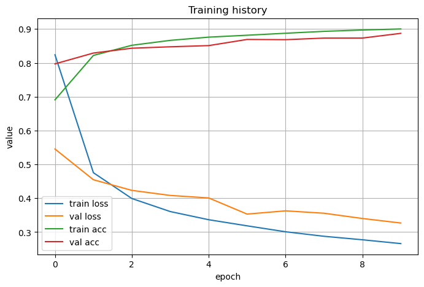

```
=== Training LeNet2 for 20 epochs ===
Epoch 1: train loss=0.8067, train acc=0.701, val loss=0.6509, val acc=0.737
Epoch 2: train loss=0.4723, train acc=0.826, val loss=0.4640, val acc=0.831
Epoch 3: train loss=0.4146, train acc=0.847, val loss=0.4399, val acc=0.837
Epoch 4: train loss=0.3768, train acc=0.860, val loss=0.4027, val acc=0.855
Epoch 5: train loss=0.3508, train acc=0.869, val loss=0.3743, val acc=0.863
Epoch 6: train loss=0.3312, train acc=0.877, val loss=0.3639, val acc=0.866
Epoch 7: train loss=0.3162, train acc=0.883, val loss=0.3411, val acc=0.876
Epoch 8: train loss=0.3034, train acc=0.887, val loss=0.3452, val acc=0.874
Epoch 9: train loss=0.2916, train acc=0.892, val loss=0.3368, val acc=0.878
Epoch 10: train loss=0.2816, train acc=0.896, val loss=0.3281, val acc=0.878
Epoch 11: train loss=0.2718, train acc=0.898, val loss=0.3250, val acc=0.883
Epoch 12: train loss=0.2637, train acc=0.901, val loss=0.3126, val acc=0.887
Epoch 13: train loss=0.2558, train acc=0.904, val loss=0.3257, val acc=0.882
Epoch 14: train loss=0.2482, train acc=0.907, val loss=0.3126, val acc=0.888
Epoch 15: train loss=0.2411, train acc=0.910, val loss=0.3206, val acc=0.886
Epoch 16: train loss=0.2347, train acc=0.912, val loss=0.3138, val acc=0.891
Epoch 17: train loss=0.2284, train acc=0.915, val loss=0.3162, val acc=0.888
Epoch 18: train loss=0.2219, train acc=0.917, val loss=0.3017, val acc=0.894
Epoch 19: train loss=0.2178, train acc=0.917, val loss=0.3212, val acc=0.888
Epoch 20: train loss=0.2126, train acc=0.918, val loss=0.3497, val acc=0.879
```

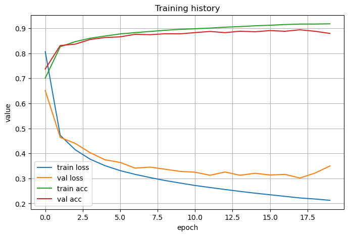

### Question 2: Modifying LeNet: Replace average pooling with max-pooling, replace the Sigmoid layer with ReLU. After doing so, redo the above experiment (Using different epochs 5, 10, 20), plot the training loss, validation loss, and validation accuracy for each training process. Discuss the changes compared to the results of original LeNet training.

The transition from LeNet with Sigmoid activation and AvgPool to ReLU and MaxPool resulted in faster convergence and better generalization performance. The original setup produced a gradual increase in validation accuracy (≈0.45 at 5 epochs, ≈0.74 at 10 epochs, ≈0.77 at 20 epochs) while maintaining high validation loss values (≈0.70 at 10 epochs and ≈0.59 at 20 epochs). The ReLU/MaxPool runs achieve high performance levels right from the start since validation accuracy reaches ≈0.86 at 5 epochs with a validation loss of ≈0.37. The validation accuracy reaches ≈0.887 while validation loss decreases to ≈0.33 during the 10th epoch. The validation accuracy reaches its peak at ≈0.894 during the 20th epoch before decreasing to ≈0.879 at the end while validation loss reaches its minimum at ≈0.30 before a small increase occurs which indicates fast optimization and superior performance with minimal overfitting after 18 epochs.

The derivative of ReLU equals 1 in its active region which enables better gradient propagation and MaxPool outperforms AvgPool because it selects the most powerful local responses which produces clearer and more discriminative features that lead to better class differentiation. The combination of these two elements produces both rapid early loss reduction and higher accuracy levels.

The new model reaches performance levels that the original model struggled to achieve during its first 20 epochs within a time frame of 5 to 10 epochs. The optimal validation point occurs between epochs 15 and 18 so early stopping would be suitable.

[output not shown]

[output not shown]

[output not shown]

[output not shown]

```
Extracting ./data/MNIST/raw/t10k-labels-idx1-ubyte.gz to ./data/MNIST/raw
```

```
=== Training LeNet on MNIST for 10 epochs ===
Epoch 1: train loss=0.2785, train acc=0.909, val loss=0.0904, val acc=0.970
Epoch 2: train loss=0.0689, train acc=0.978, val loss=0.0622, val acc=0.980
Epoch 3: train loss=0.0476, train acc=0.985, val loss=0.0453, val acc=0.986
Epoch 4: train loss=0.0384, train acc=0.988, val loss=0.0372, val acc=0.988
Epoch 5: train loss=0.0313, train acc=0.990, val loss=0.0402, val acc=0.986
Epoch 6: train loss=0.0267, train acc=0.992, val loss=0.0432, val acc=0.987
Epoch 7: train loss=0.0218, train acc=0.993, val loss=0.0390, val acc=0.988
Epoch 8: train loss=0.0204, train acc=0.994, val loss=0.0396, val acc=0.988
Epoch 9: train loss=0.0169, train acc=0.994, val loss=0.0354, val acc=0.989
Epoch 10: train loss=0.0140, train acc=0.996, val loss=0.0325, val acc=0.990
```

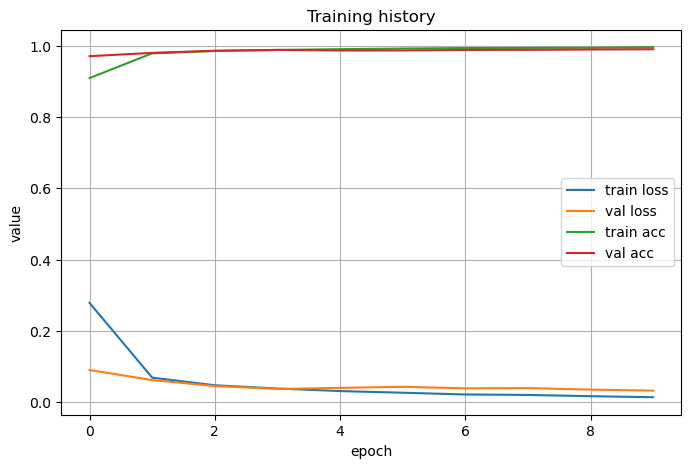